# Recalling Words

```r
# Play the chunk above and this one to get the data into your Console
View(Friendly)
?Friendly
```

#### Background

Many teachers and other educators are interested in understanding how to best deliver new content to students. In general, they have two choices of how to do this.

1. The Meshed Approach
   - Deliver new content while simultaneously reviewing previously understood content.
2. The Before Approach
   - Deliver new content after fully reviewing previously understood content.

A study was performed to determine whether the *Meshed* or *Before* approaches to delivering content had any positive benefits on memory recall.

# Hypothesis

This study has the potential of helping us understand which teaching methods work the best. We are going to just analyze the “Before” and “Meshed” methods and ask the question, is there a difference between the two methods in their effect on memory recall?

Our null and alternative hypothese are thus:
$$H_0: \text{ Difference in Medians}= 0$$

$$H_a: \text{ Difference in Medians} \ne 0$$

With the level of significance being:
$$\alpha = 0.05$$

# Analysis

The table below shows a quick summary of the two methods, “Before” and “Meshed”.

```r
friendly2 <- Friendly %>%
  mutate(condition = as.character(condition)) %>%
  filter(condition != "SFR")

friendly2 %>%
  group_by("Method" = condition) %>%
  summarise(Min = min(correct),
            Median = median(correct),
            Mean = mean(correct),
            Max = max(correct),
            "$\\sigma$" = sd(correct),
            "# of individuals" = n()) %>%
  pander(caption = "Summary of Correct words by Method")
```

Summary of Correct words by Method

| Method | Min | Median | Mean | Max | $\sigma$ | # of individuals |
| --- | --- | --- | --- | --- | --- | --- |
| Before | 24 | 39 | 36.6 | 40 | 5.337 | 10 |
| Meshed | 30 | 36.5 | 36.6 | 40 | 3.026 | 10 |

I would like to point out that while the Means of both groups are equal at 36.6, according to the summaries above, the data’s distribution is not necessarily equal. We will be looking primary at the medians instead, which are different according to the table above at 39 and 36.5. To further illistrate this, see the boxplot below. This side-by-side boxplot shows where all the scores line up in each respective group.

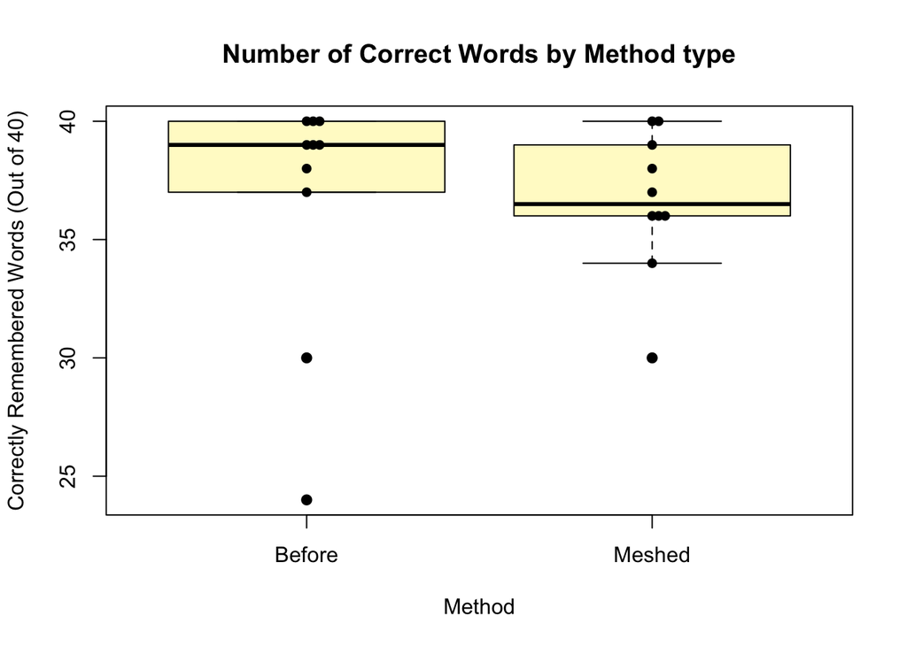

```r
boxplot(correct ~ condition,
        data = friendly2,
        xlab = "Method",
        ylab = "Correctly Remembered Words (Out of 40)",
        main = "Number of Correct Words by Method type",
        col = "lemonchiffon",
        cex = 1)
stripchart(correct ~ condition, data = friendly2, pch=16, method="stack",
           col="black", add=TRUE, vertical = TRUE)
```

While this is helpful to visualize, it can still be difficult to see a clear difference in the distributions of the “Before” and “Meshed” Method types. With smaller sample sizes of 10 per group and where the distribution of the data not normal, lets now run this data through a Wilcoxon Rank Sum Test.

It’s important to note that since there are ties in the data(as shown in the Boxplot above by the dots that are side by side) the test will be an approximation but will still have enough accuracy to show if there is sufficient evidence to support the Null hypothesis or reject it.

```r
wilcox.test(correct ~ condition, data = friendly2, mu = 0, alternative = "two.sided", conf.level = 0.95) %>%
  pander()
```

Wilcoxon rank sum test with continuity correction: `correct` by `condition`

| Test statistic | P value | Alternative hypothesis |
| --- | --- | --- |
| 62 | 0.378 | two.sided |

When we compare the p-value to $\alpha$ we get:

$$(p = .378 > \alpha)$$

From the Wilcoxon Rank Sum Test, we can see that the p-value, 0.378, is greater than $\alpha$, 0.05, showing that there is not sufficient evidence to reject the null hypothesis.

# Interpretation

Since there is not sufficient evidence to reject the null hypothesis, we can reasonable conclude that neither the “Before” or “Meshed” methods of memory recall are better than the other. This is a valuable insight, as the best method of memory recall has long been a topic of debate in the teaching world. Potential reasons why these methods might not stand out against each other could include the diversity in students method of learning and retaining information. It would be an interesting study to include students demographics and analyze locations, social standing, access to resources, etc… to determine if one method appeals to one demographic over another.